# Linear Regression

```python
# install packages
import numpy as np # For matrix and numerical calculations; foundation of pandas
import pandas as pd # For dataframe manipulation
import seaborn as sns # For visualizations and plotting
import matplotlib.pyplot as plt # For visualizations and plotting
%matplotlib inline

# import packages for splitting data and running linear regression
from sklearn.model_selection import train_test_split # For splitting the data into training/test datasets
import statsmodels.api as sm # For linear regression modeling
from statsmodels.compat import lzip # for additional capabilities like plotting
from sklearn import linear_model, preprocessing # For linear regression modeling
from sklearn.metrics import mean_squared_error, r2_score # For evaluating models
from sklearn import metrics # snagging the other metrics, including MAE, MSE, and RMSE.
```

```python
#reading in Cleaned data from EDA
df = pd.read_csv('cleaned_tornado.csv')
df.head()
```

|  | Year | Month | Day | Date | State | Magnitude | Injuries | Fatalities | StartingLatitude | StartingLatitude.1 | EndingLatitude | EndingLongitude | Length | Width |
| --- | --- | --- | --- | --- | --- | --- | --- | --- | --- | --- | --- | --- | --- | --- |
| 0 | 1950 | 1 | 3 | 1/3/1950 | IL | 3 | 3 | 0 | 39.10 | -89.30 | 39.12 | -89.23 | 3.6 | 130 |
| 1 | 1950 | 1 | 3 | 1/3/1950 | MO | 3 | 3 | 0 | 38.77 | -90.22 | 38.83 | -90.03 | 9.5 | 150 |
| 2 | 1950 | 1 | 3 | 1/3/1950 | OH | 1 | 1 | 0 | 40.88 | -84.58 | 0.00 | 0.00 | 0.1 | 10 |
| 3 | 1950 | 1 | 13 | 1/13/1950 | AR | 3 | 1 | 1 | 34.40 | -94.37 | 0.00 | 0.00 | 0.6 | 17 |
| 4 | 1950 | 1 | 25 | 1/25/1950 | IL | 2 | 0 | 0 | 41.17 | -87.33 | 0.00 | 0.00 | 0.1 | 100 |

```python
#renaming column
df.rename(columns={'StartingLatitude.1': 'StartingLongitude'}, inplace=True)
df.head()
```

|  | Year | Month | Day | Date | State | Magnitude | Injuries | Fatalities | StartingLatitude | StartingLongitude | EndingLatitude | EndingLongitude | Length | Width |
| --- | --- | --- | --- | --- | --- | --- | --- | --- | --- | --- | --- | --- | --- | --- |
| 0 | 1950 | 1 | 3 | 1/3/1950 | IL | 3 | 3 | 0 | 39.10 | -89.30 | 39.12 | -89.23 | 3.6 | 130 |
| 1 | 1950 | 1 | 3 | 1/3/1950 | MO | 3 | 3 | 0 | 38.77 | -90.22 | 38.83 | -90.03 | 9.5 | 150 |
| 2 | 1950 | 1 | 3 | 1/3/1950 | OH | 1 | 1 | 0 | 40.88 | -84.58 | 0.00 | 0.00 | 0.1 | 10 |
| 3 | 1950 | 1 | 13 | 1/13/1950 | AR | 3 | 1 | 1 | 34.40 | -94.37 | 0.00 | 0.00 | 0.6 | 17 |
| 4 | 1950 | 1 | 25 | 1/25/1950 | IL | 2 | 0 | 0 | 41.17 | -87.33 | 0.00 | 0.00 | 0.1 | 100 |

```python
# Split the df based on 'Year'
condition = df['Year'] <= 2006  # Define the condition
df_older = df[condition]  # Select rows that meet the condition

df = df[~condition]  # Select rows that do not meet the condition

df.head()
```

|  | Year | Month | Day | Date | State | Magnitude | Injuries | Fatalities | StartingLatitude | StartingLongitude | EndingLatitude | EndingLongitude | Length | Width |
| --- | --- | --- | --- | --- | --- | --- | --- | --- | --- | --- | --- | --- | --- | --- |
| 49296 | 2007 | 1 | 4 | 1/4/2007 | LA | 1 | 0 | 0 | 30.60 | -91.45 | 30.62 | -91.47 | 1.83 | 75 |
| 49297 | 2007 | 1 | 4 | 1/4/2007 | LA | 1 | 15 | 2 | 29.92 | -91.80 | 30.05 | -91.73 | 15.07 | 100 |
| 49298 | 2007 | 1 | 5 | 1/5/2007 | GA | 0 | 0 | 0 | 33.27 | -84.56 | 33.29 | -84.55 | 1.68 | 200 |
| 49299 | 2007 | 1 | 5 | 1/5/2007 | GA | 0 | 0 | 0 | 31.32 | -82.47 | 31.34 | -82.47 | 2.00 | 100 |
| 49300 | 2007 | 1 | 5 | 1/5/2007 | GA | 1 | 0 | 0 | 33.36 | -84.90 | 33.42 | -84.84 | 5.39 | 200 |

### Research Question

Can length and width be predicted based on tornado characteristics and injuries/fatalities?  
Analysis method: Linear Regression (modeling a continuous outcome)

```python
# List of column names to be dropped, dropping all none categorical variables
columns_to_drop = ['Magnitude', 'Year', 'Month', 'Day', 'Date', 'State','StartingLatitude','StartingLongitude','EndingLatitude','EndingLongitude']
#copying df for analysis on length and width
df= df.copy()
df.drop(columns=columns_to_drop, axis=1,inplace=True)
df.head()
```

|  | Injuries | Fatalities | Length | Width |
| --- | --- | --- | --- | --- |
| 49296 | 0 | 0 | 1.83 | 75 |
| 49297 | 15 | 2 | 15.07 | 100 |
| 49298 | 0 | 0 | 1.68 | 200 |
| 49299 | 0 | 0 | 2.00 | 100 |
| 49300 | 0 | 0 | 5.39 | 200 |

#### 1. Length

```python
#looking at dependent variable length
df["Length"].describe()
```

```
count    18262.000000
mean         3.545453
std          6.528550
min          0.010000
25%          0.380000
50%          1.460000
75%          4.110000
max        168.530000
Name: Length, dtype: float64
```

```python
# isolating our explanatory (independent) and outcome (dependent) variables

# Include all columns for our explanatory variables except the outcome variable
X = df.drop(["Length"],axis=1)

# Create constant (y-intercept) for the model
X = sm.add_constant(X)

# generate our outcome (dependent) variable
y = df[["Length"]]

# splitting the data into training/test sets
X_train, X_test, y_train, y_test = train_test_split(X, y, test_size = 0.25, random_state = 123)
```

```python
# check to make sure the data is the correct shape
print(X_train.shape, y_train.shape)
print(X_test.shape, y_test.shape)
```

```
(13696, 4) (13696, 1)
(4566, 4) (4566, 1)
```

```python
### step 1: fit/evaluate the model on training data ###

# Create the model on our training data
model = sm.OLS(y_train, X_train)

# Fit the model
model_results = model.fit()
```

```python
# evaluate our model
model_results.summary()
```

OLS Regression Results

| Dep. Variable: | Length | R-squared: | 0.378 |
| --- | --- | --- | --- |
| Model: | OLS | Adj. R-squared: | 0.377 |
| Method: | Least Squares | F-statistic: | 2768. |
| Date: | Tue, 30 May 2023 | Prob (F-statistic): | 0.00 |
| Time: | 15:41:08 | Log-Likelihood: | -42105. |
| No. Observations: | 13696 | AIC: | 8.422e+04 |
| Df Residuals: | 13692 | BIC: | 8.425e+04 |
| Df Model: | 3 |  |  |
| Covariance Type: | nonrobust |  |  |

|  | coef | std err | t | P>\|t\| | [0.025 | 0.975] |
| --- | --- | --- | --- | --- | --- | --- |
| const | 1.3004 | 0.053 | 24.710 | 0.000 | 1.197 | 1.404 |
| Injuries | 0.0228 | 0.004 | 5.735 | 0.000 | 0.015 | 0.031 |
| Fatalities | 0.5127 | 0.041 | 12.365 | 0.000 | 0.431 | 0.594 |
| Width | 0.0137 | 0.000 | 78.411 | 0.000 | 0.013 | 0.014 |

| Omnibus: | 13288.133 | Durbin-Watson: | 2.002 |
| --- | --- | --- | --- |
| Prob(Omnibus): | 0.000 | Jarque-Bera (JB): | 3140065.778 |
| Skew: | 4.153 | Prob(JB): | 0.00 |
| Kurtosis: | 76.712 | Cond. No. | 364. |

Notes:  
[1] Standard Errors assume that the covariance matrix of the errors is correctly specified.

```python
### Step 2: Use the model to obtain predictions on the test data ###

# obtain our predicted values using our testing data
y_pred = model_results.predict(X_test)
```

```python
# let's take a look at our other metrics of model performance
print('MAE :', metrics.mean_absolute_error(y_test, y_pred))
print('MSE :', metrics.mean_squared_error(y_test, y_pred))
print('RMSE :', np.sqrt(metrics.mean_squared_error(y_test, y_pred)))
```

```
MAE : 2.634480624365856
MSE : 23.771802453057607
RMSE : 4.875633543762042
```

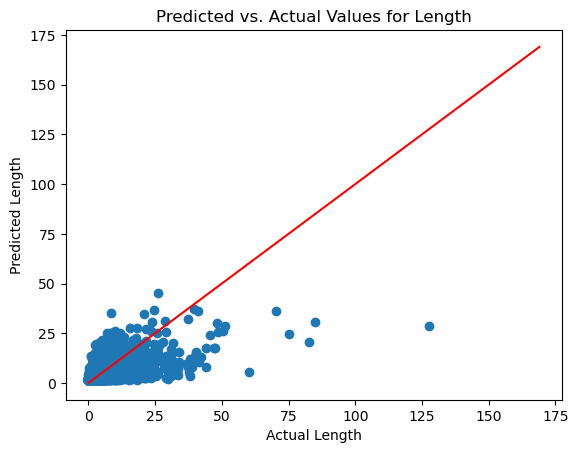

```python
### Step 3: Visualize the predicted vs. actual values ###
# plot the actual vs. predicted values against one another to visually assess how we did

# Build a scatterplot
plt.scatter(y_test, y_pred)

# Add a line for perfect correlation
plt.plot([x for x in range(0,170)],[x for x in range(0,170)], color='red')

# Label it nicely
plt.title("Predicted vs. Actual Values for Length")
plt.xlabel("Actual Length")
plt.ylabel("Predicted Length")
```

**Interpretations:**

- Injuries: For every injury, the tornado length increases by 0.0228 miles, or about 120 feet.
- Fatalities: For every fatality, the tornado length increases by 0.5127 miles, or a little over half a mile.
- Width: For every yard of width in the tornado, the tornado length increases by 0.0137 miles or about 72 feet.